# Bio for Justine Cheung

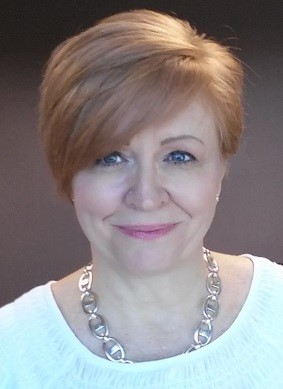

## My Home Department

[ASU School of Social Work](https://socialwork.asu.edu/)

## Interest in the Course

I am the program coordinator for ASU Bridging Success - a student success program that supports students at the university who have experienced foster care. Bridging Success was recently awarded a grant that will provide funding for the next three years. Part of the grant agreement is that we provide our funders with data analysis regarding recruitment and retention of our specific student population. I felt that the needs of our grant funders and the learning outcomes for this class aligned well. Also, I can learn another skill to build my CV as I go on the PhD job market in another year or so. It’s a win/win all the way around!

## Three Things About Me

1. I lived in China for 13 years and Mandarin Chinese is my second language. (I realize this is a 2 for 1!)
2. I love the work I do here at ASU.
3. I’m a single mom with 8 children - but thankfully only 3 still live at home.

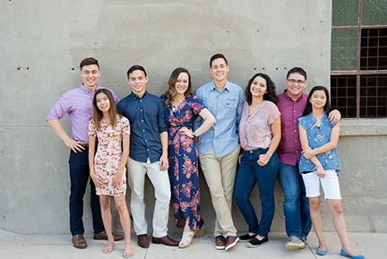

## BONUS: Something Weird in my Playlist

[figure not shown]

*Axis of Awesome’s 4 Chord Song is a old video but it always reminds me how we often make things much harder than they need to be.*